## ##Computer Assignment 2 Answers File

## Please write your answers into the space below the questions. Knit this file when you are done to check that all code runs. Remember to rename the file to contain *your actual* Last and First name.

RUN THE FOLLOWING PREREQUISITE CHUNK

```r
#--for Q1
id <- c("ENO2", "TDH3", "RPL39", "GAL4", "POL12", "EST2") #protein codes
protName <- c("enolase", "glyceraldehyde-3-phosphate dehydrogenase", "60S ribosomal protein L39", "regulatory protein Gal4", "DNA polymerase subunit alpha B", "telomerase reverse transcriptase") #full protein names
abundance <- c(24563, 22369, 16232, 32.3, 13.7, 0.01) #cellular abundance in ppm
length <- c(437, 332, 51, 881, 705, 884) #number of amino acids
yeastProt <- data.frame(id, protName, abundance, length)
#--for Q2 and onwards
if (!requireNamespace("BiocManager", quietly = TRUE))
    install.packages("BiocManager") #installs Bioconductor
BiocManager::install("multtest") #uses Bioconductor's installation tool to install the multtest package
library(multtest) #loads a library of tools included in the multtest package, including the golub data
data(golub) #loads the golub data set
```

–

```r
yeastProt[yeastProt[,3] > 500, 3]
```

```
## [1] 24563 22369 16232
```

1.1  
Indexes into the yeastProt dataframe and selects only the rows such that the value in the third column is greater than 500. Out of these rows, then it selects only the values in the third column.

```r
#yeastProt[,1]
#yeastProt[1,]
#yeastProt[1:3,c(1,3)]
#yeastProt[1,1]
```

1.2  
The first argument into the [] brackets after the name of the dataframe tells you what rows to select, and the second argument specifies which columns to select. The columns index from left to right, and rows from top to bottom.

1.3

```r
# Rewrite the above command (yeastProt[yeastProt[,3] > 500, 3]) with two different notations for data frame indexing that generate the same output.

yeastProt[1:3, "abundance"]
```

```
## [1] 24563 22369 16232
```

```r
yeastProt$abundance[1:3]
```

```
## [1] 24563 22369 16232
```

1.4

```r
# Construct a command that generates a new data frame named filteredyeastProt that consists of information from proteins with an abundance greater than 21000 ppm.

filteredyeastProt <- yeastProt[yeastProt[,"abundance"] > 21000,]
filteredyeastProt
```

```
##     id                                 protName abundance length
## 1 ENO2                                  enolase     24563    437
## 2 TDH3 glyceraldehyde-3-phosphate dehydrogenase     22369    332
```

2.1  
In a matrix in R, you cannot mix different types of data. The gene expression data is numerical, while the gene names data is text so they cannot be stored in a single matrix.

2.2

```r
# Using the information encoded in golub.cl, which columns in the golub matrix represent patients with ALL and which columns represent patients with AML?

# 1 codes for AML; 0 for ALL

# patients with AML
AML_pats <- which(golub.cl == 1)
AML_pats
```

```
##  [1] 28 29 30 31 32 33 34 35 36 37 38
```

```r
# patients with ALL
ALL_pats <- which(golub.cl == 0)
ALL_pats
```

```
##  [1]  1  2  3  4  5  6  7  8  9 10 11 12 13 14 15 16 17 18 19 20 21 22 23 24 25
## [26] 26 27
```

2.3  
The row that contains the data for cyclin D3 is 1042

```r
# find the row that contains the data for cyclin D3

cycD3_row <- grep("cyclin D3", golub.gnames[,2], ignore.case = TRUE)
cycD3_row
```

```
## [1] 1042
```

2.4

```r
# calculate the mean expression of cyclin D3 mRNA in ALL patients and then in AML patients
cycD3_ALL <- mean(golub[cycD3_row, ALL_pats])
cycD3_ALL
```

```
## [1] 1.893883
```

```r
cycD3_AML <- mean(golub[cycD3_row, AML_pats])
cycD3_AML
```

```
## [1] 0.6355909
```

2.5

```r
# Run the t-test on cyclin D3 expression values, report the p-value, and interpret its meaning
t.test(golub[cycD3_row,ALL_pats],golub[cycD3_row,AML_pats])
```

```
##
##  Welch Two Sample t-test
##
## data:  golub[cycD3_row, ALL_pats] and golub[cycD3_row, AML_pats]
## t = 6.3186, df = 16.118, p-value = 9.871e-06
## alternative hypothesis: true difference in means is not equal to 0
## 95 percent confidence interval:
##  0.8363826 1.6802008
## sample estimates:
## mean of x mean of y
## 1.8938826 0.6355909
```

The p value is 9.871 * 10e-6, which is much less than 0.05. This implies that we can conclude that the different values for the two groups (AML patients and ALL patients) did not just occur due to chance.

2.6

```r
meanALL2 <- apply(golub[,ALL_pats], 1, mean)

# second apply command to compute the mean expression of each gene for AML patients
meanAML2 <- apply(golub[,AML_pats], 1, mean)

# the absolute value of the difference in means between ALL and AML patients
absDiff <- abs(meanALL2 - meanAML2)
```

2.7

```r
# return the names of the 7 genes that have the largest absolute difference in mean expression between ALL and AML patients

o <- order(absDiff, decreasing=TRUE)
golub.gnames[o[1:7], 2]
```

```
## [1] "CST3 Cystatin C (amyloid angiopathy and cerebral hemorrhage)"
## [2] "INTERLEUKIN-8 PRECURSOR"
## [3] "Interleukin 8 (IL8) gene"
## [4] "DF D component of complement (adipsin)"
## [5] "MPO Myeloperoxidase"
## [6] "TCL1 gene (T cell leukemia) extracted from H.sapiens mRNA for Tcell leukemia/lymphoma 1"
## [7] "Azurocidin gene"
```

2.8 (a) Compare the top 5 differentially expressed genes to those that were used as the predictive set in Figure 3 of the Golub et al. paper which of these genes is not used in the set of predictors?

MPO Myeloperoxidase was not used in the set of predictors in Figure 3 of the Golub at al. paper

2.8 (b) Why might a ranking based solely on differences in mean expression be an inadequate metric for determining the best predictors of cancer subtype?  
There may also be a high variance of the gene expression within each subtype. This would make using only the means less accurate.

2.8 (c) What might be a better statistical metric for identifying genes to become part of the predictive set? (If you are stuck, feel free to browse the Golub et al. paper to see what they actually did, though this is not necessarily the only correct answer.)  
One method of identifying genes to become a part of the predictive set is using a method called “neighborhood analysis”. They define an “idealized expression pattern” corresponding to a gene that is uniformly high in one class and uniformly low in the other. Then, they test if there is a high density of genes “nearby” this idealized pattern. These genes are selected for the predictive set.

2.9

```r
gol.fac <- factor(golub.cl, levels=c(0,1), labels = c("ALL","AML"))
gol.fac
```

```
##  [1] ALL ALL ALL ALL ALL ALL ALL ALL ALL ALL ALL ALL ALL ALL ALL ALL ALL ALL ALL
## [20] ALL ALL ALL ALL ALL ALL ALL ALL AML AML AML AML AML AML AML AML AML AML AML
## Levels: ALL AML
```

The command is taking the golub.cl vector and creating a new vector that replaces the 0, 1 labels to “ALL” and “AML” respectively.

3.1

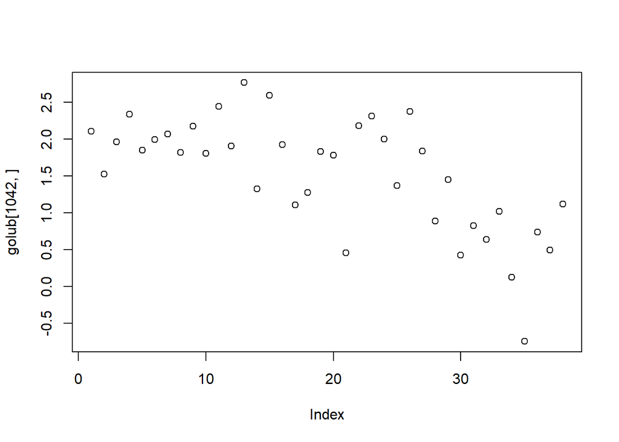

```r
# makes a scatter plot of the gene expression data of the 1042th gene in the golub database. The patients are on the x-axis, and the respective gene expression is on the y-axis.
# first argument adds the data to the plot
plot(golub[1042,])
```

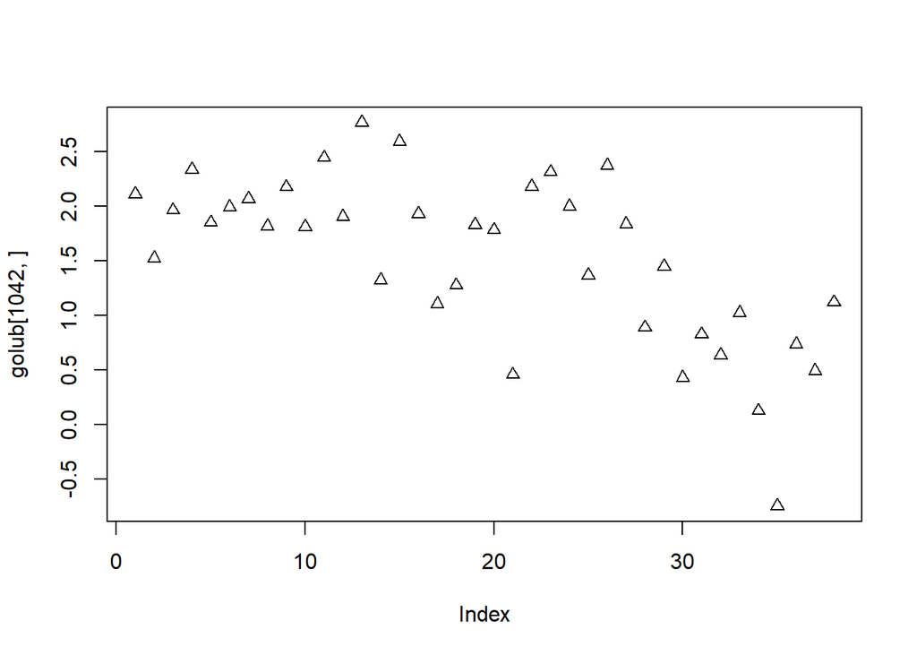

```r
# pch=2 -- changes the specific character that will be plotted. Switches from circles to triangles
plot(golub[1042,], pch=2)
```

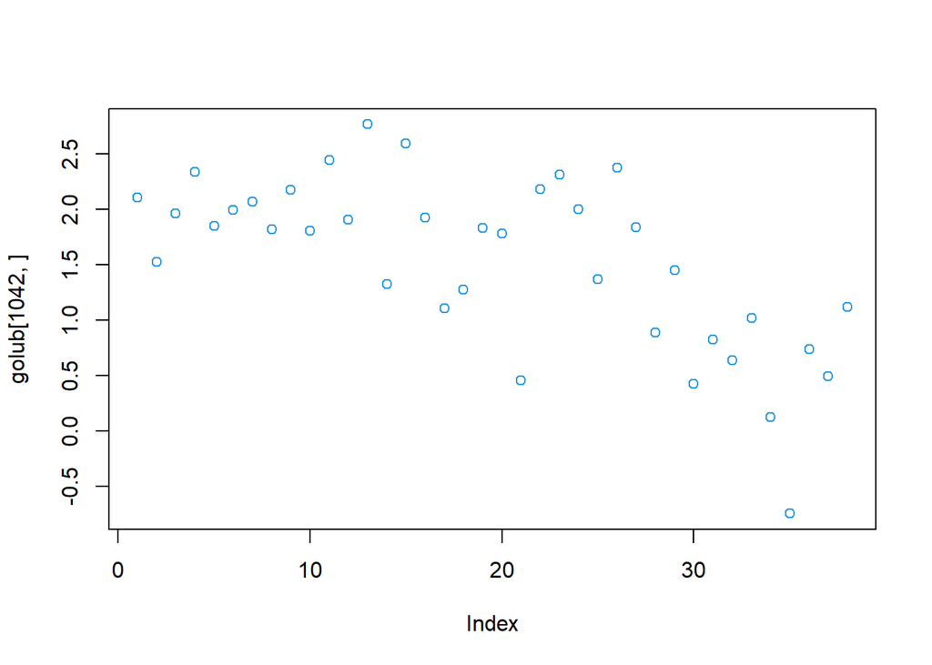

```r
# col=28 -- changes the color of the points plotted to blue
plot(golub[1042,], col=28)
```

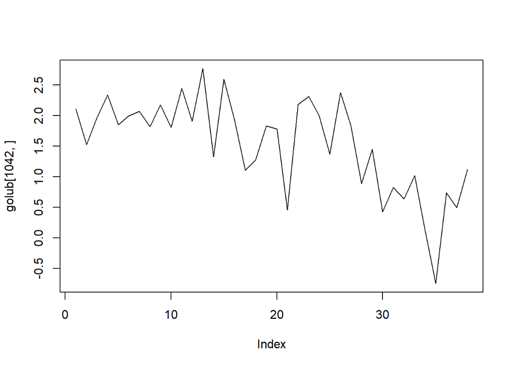

```r
# type='l' -- changes the type of plot to a line graph
plot(golub[1042,], type='l')
```

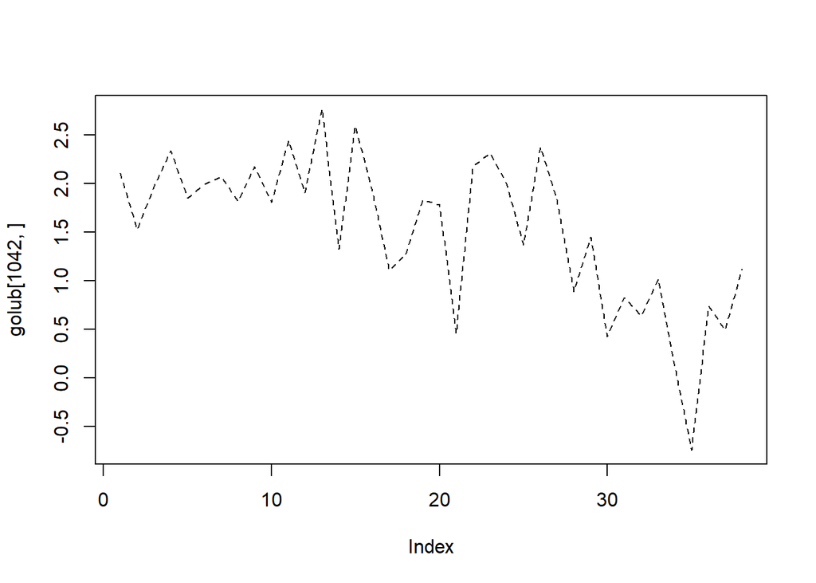

```r
# lty=2 -- changes the solid line to dashed line
plot(golub[1042,], type='l', lty=2)
```

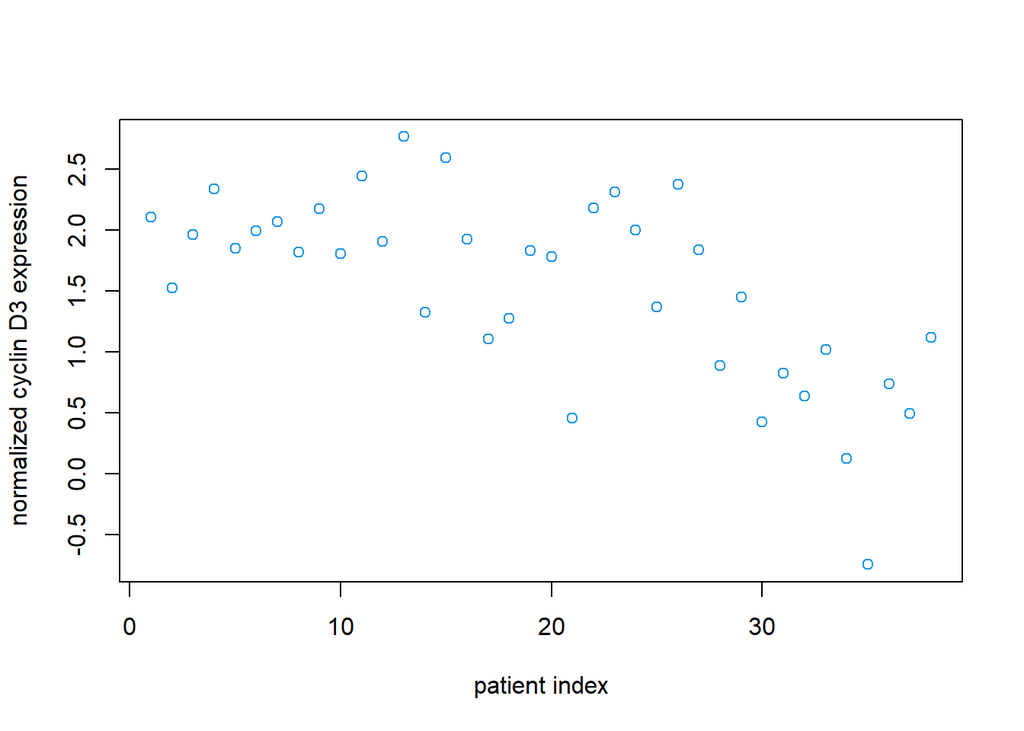

```r
# xlab="patient index" -- adds x label to the graph
# ylab="normalized cyclin D3 expression" -- adds y label to the graph
plot(golub[1042,], col=28, xlab="patient index", ylab="normalized cyclin D3 expression")
```

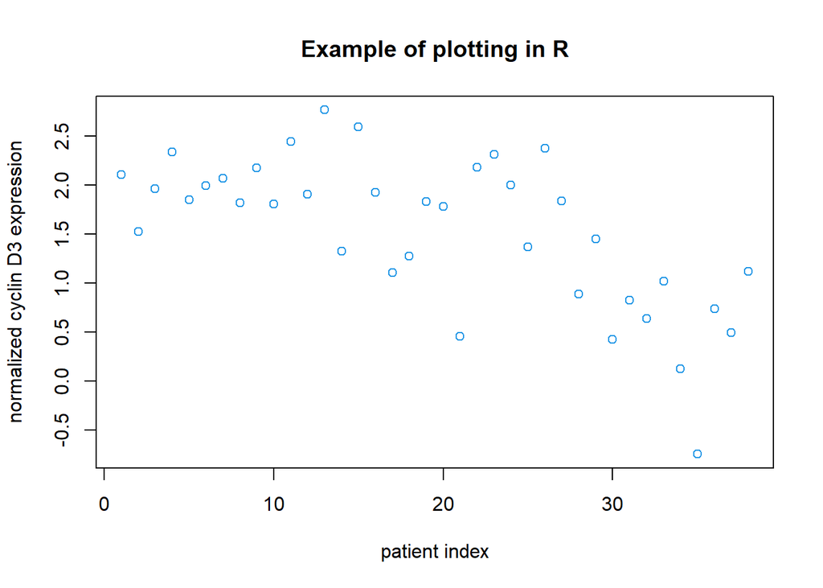

```r
# main="Example of plotting in R" -- adds a title to the plot
plot(golub[1042,], col=28, xlab="patient index", ylab="normalized cyclin D3 expression",main="Example of plotting in R")
```

3.2

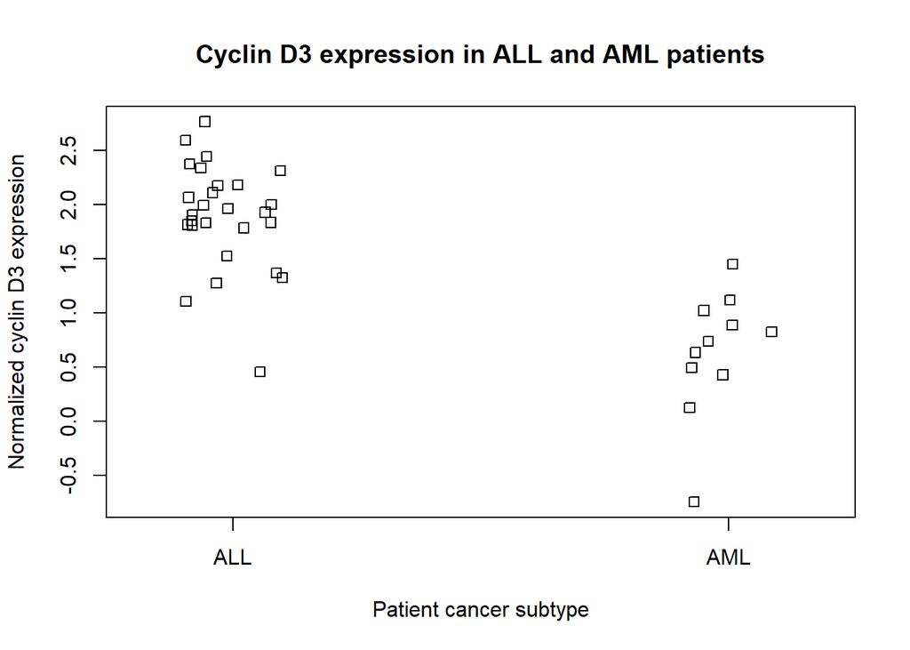

```r
stripchart(golub[1042,] ~ gol.fac, main="Cyclin D3 expression in ALL and AML patients", xlab="Patient cancer subtype", ylab="Normalized cyclin D3 expression", method="jitter", vertical=TRUE)
```

3.3a

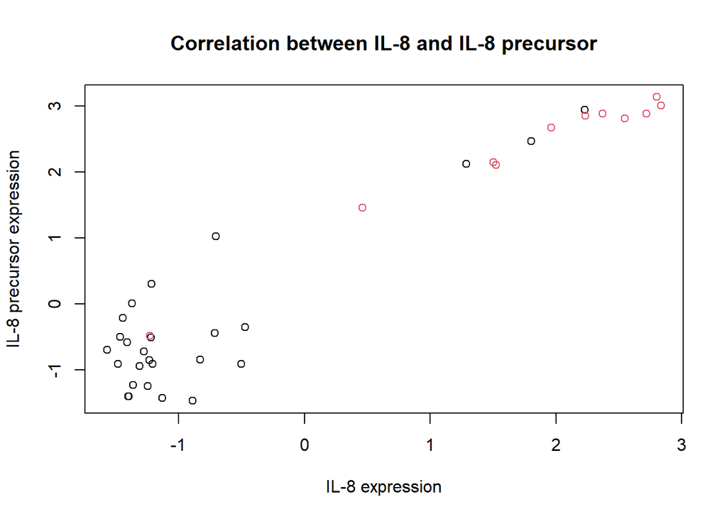

```r
# create a scatter plot of the gene expression values for two genes that are used as subtype predictors: IL-8 (row 2663 of golub) and IL-8 precursor (row 2664)

plot(golub[2663,], golub[2664,], col=gol.fac, xlab="IL-8 expression", ylab="IL-8 precursor expression", main="Correlation between IL-8 and IL-8 precursor")
```

3.3b

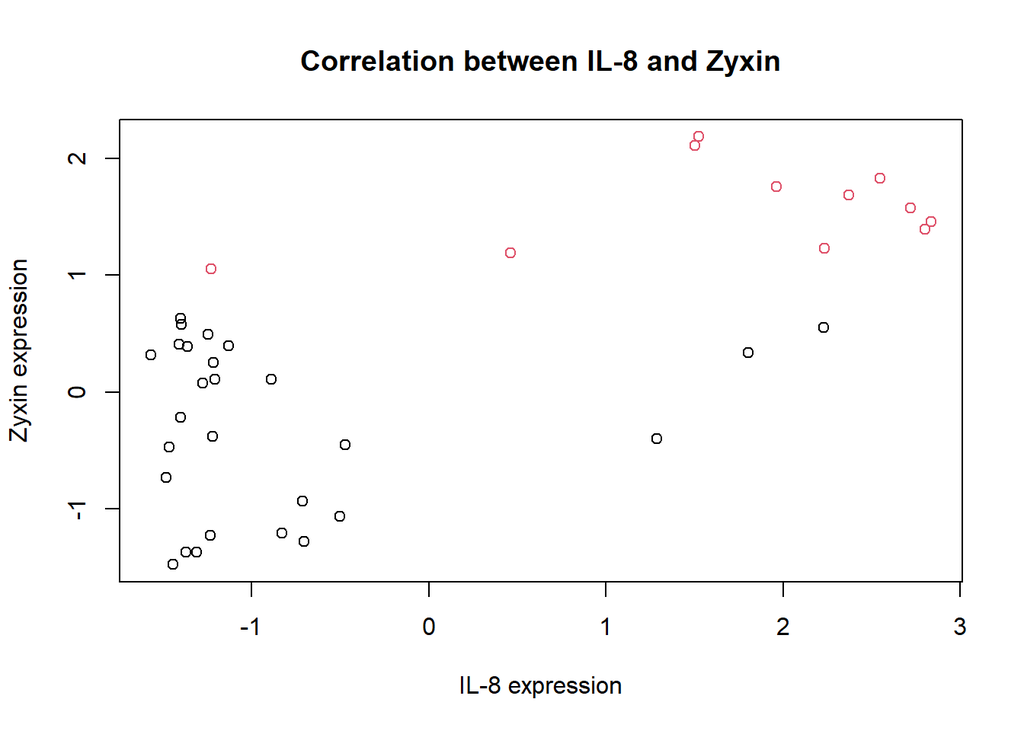

```r
# create a scatter plot of the gene expression values for two genes that are used as subtype predictors: IL-8 (row 2663 of golub) and Zyxin (row 2124)

plot(golub[2663,], golub[2124,], col=gol.fac, xlab="IL-8 expression", ylab="Zyxin expression", main="Correlation between IL-8 and Zyxin")
```

Both the IL-8 precursor and Zyxin seem to have a positive correlation with the IL-8 expression. However, the correlation between IL-8 and the IL-8 precursor visually looks stronger due to the lesser variance and stronger linear trend (atleast visually).

3.4

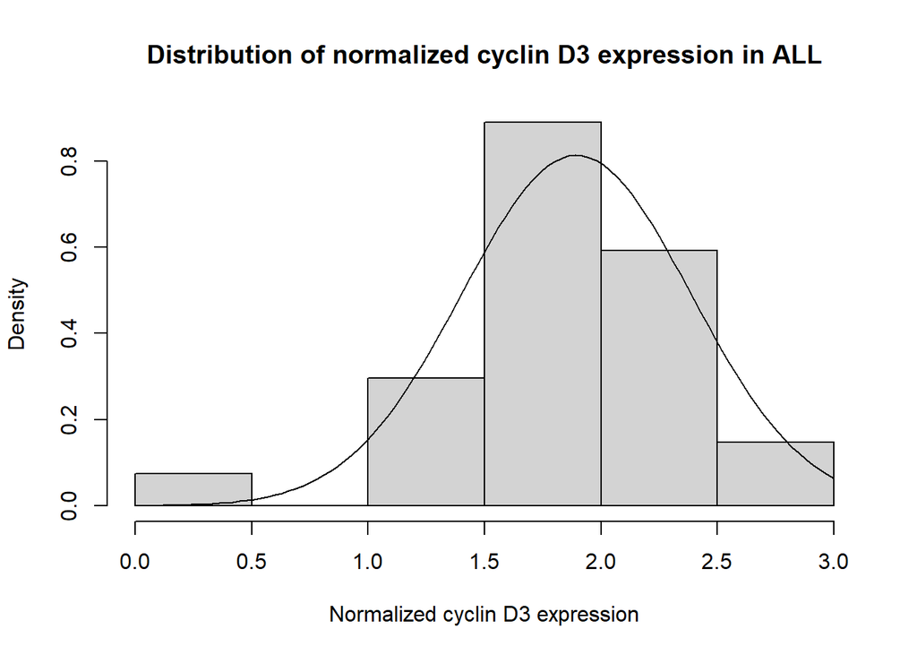

```r
# histogram of the expression of cyclin D3 in ALL patients
hist(golub[1042,gol.fac=="ALL"], freq=FALSE, xlab="Normalized cyclin D3 expression", main="Distribution of normalized cyclin D3 expression in ALL")

# overlay the normal distribution curve
curve(dnorm(x, mean=mean(golub[1042,gol.fac=="ALL"]), sd=sd(golub[1042,gol.fac=="ALL"])), add=TRUE)
```

3.5

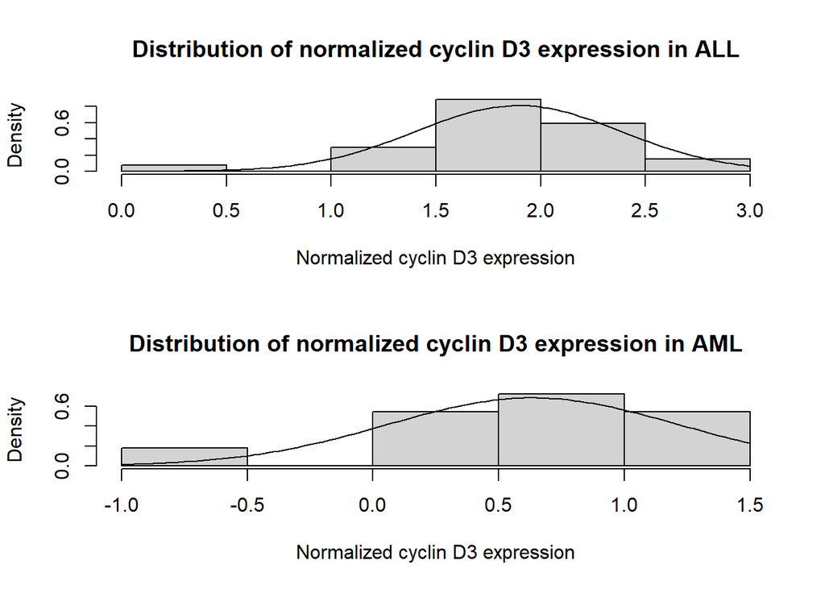

```r
# Use the par() function to display this plot and the plot of cyclin D3 expression in ALL from 3.4 in a 2x1 array (2 rows and 1 column).
par(mfrow=c(2, 1))


# plot a histogram and normal curve for the distribution of normalized cyclin D3 expression in ALL.
hist(golub[1042,gol.fac=="ALL"], freq=FALSE, xlab="Normalized cyclin D3 expression", main="Distribution of normalized cyclin D3 expression in ALL")
curve(dnorm(x, mean=mean(golub[1042,gol.fac=="ALL"]), sd=sd(golub[1042,gol.fac=="ALL"])), add=TRUE)

# plot a histogram and normal curve for the distribution of normalized cyclin D3 expression in AML.
hist(golub[1042,gol.fac=="AML"], freq=FALSE, xlab="Normalized cyclin D3 expression", main="Distribution of normalized cyclin D3 expression in AML")
curve(dnorm(x, mean=mean(golub[1042,gol.fac=="AML"]), sd=sd(golub[1042,gol.fac=="AML"])), add=TRUE)
```

Visually, it looks as though the cyclic D3 expression in ALL is more normally distributed.

3.6

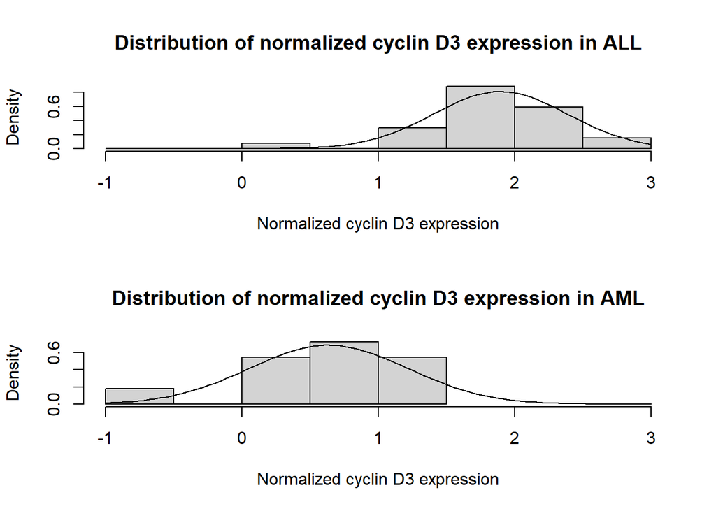

```r
# Use the par() function to display this plot and the plot of cyclin D3 expression in ALL from 3.4 in a 2x1 array (2 rows and 1 column).
par(mfrow=c(2, 1))


# plot a histogram and normal curve for the distribution of normalized cyclin D3 expression in ALL.
hist(golub[1042,gol.fac=="ALL"], freq=FALSE, xlab="Normalized cyclin D3 expression", main="Distribution of normalized cyclin D3 expression in ALL", xlim=c(-1,3))
curve(dnorm(x, mean=mean(golub[1042,gol.fac=="ALL"]), sd=sd(golub[1042,gol.fac=="ALL"])), add=TRUE)

# plot a histogram and normal curve for the distribution of normalized cyclin D3 expression in AML.
hist(golub[1042,gol.fac=="AML"], freq=FALSE, xlab="Normalized cyclin D3 expression", main="Distribution of normalized cyclin D3 expression in AML", xlim=c(-1,3))
curve(dnorm(x, mean=mean(golub[1042,gol.fac=="AML"]), sd=sd(golub[1042,gol.fac=="AML"])), add=TRUE)
```

3.7a

```r
# determine how many genes with the label “oncogene” are in the gene expression data set
onc <- grep("oncogene", golub.gnames[,2], ignore.case=TRUE)
numOnc <- length(onc)
numOnc
```

```
## [1] 47
```

There are 47 genes within the gene expression dataset that are labeled as oncogenes.

3.7b

```r
# Which of the oncogenes is the most highly differentially expressed?
index <- onc[order(absDiff[onc], decreasing=TRUE)[1]]
golub.gnames[index, 2]
```

```
## [1] "GRO2 GRO2 oncogene"
```

GRO2 GRO2 oncogene is the most highly differentially expressed oncogene.

3.7c

```r
# Is this gene in the top 50 highly differentially expressed genes from the whole data set?

index %in% order(absDiff, decreasing=TRUE)[1:50]
```

```
## [1] TRUE
```

Yes, this gene is in the top 50 highly differentially expressed genes from the whole data set.

3.7d

No, the gene is not one of the 50 identified as a predictive tool in Figure 3 of the Golub et al. paper. One reason for this is that the Golub paper used a different method for selecting the 50 predictor genes. Their different method (not just the absolute difference in expression means) may not have placed this gene in the top 50.

3.8

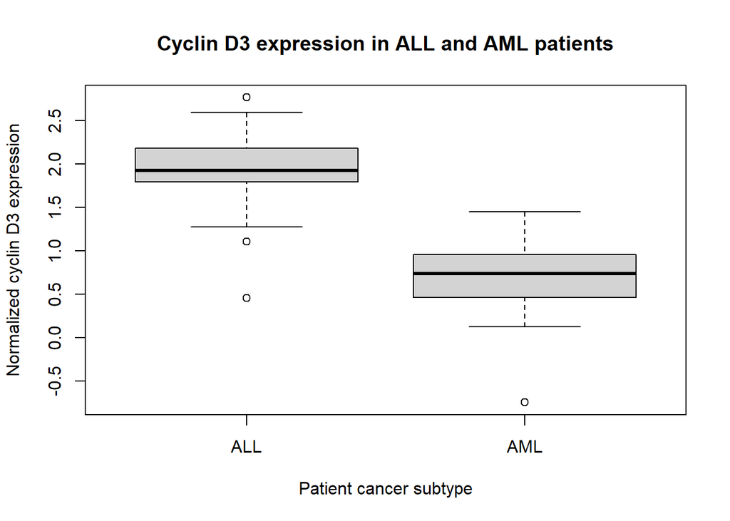

```r
boxplot(golub[1042,] ~ gol.fac, main="Cyclin D3 expression in ALL and AML patients", xlab="Patient cancer subtype", ylab="Normalized cyclin D3 expression")
```

A boxplot provides additional information like the median, the interquartile range, the minimum, and the maximum of the data. A stripchart may be preferred when you want the viewer to see the individual data points. A boxplot may be used in situations where there are a lot more data points and only the summary statistics (median, quartiles, min, max) are necessary for the viewer to see. A stripchart may be used when there are much fewer data points and individual data points are more important.

3.9

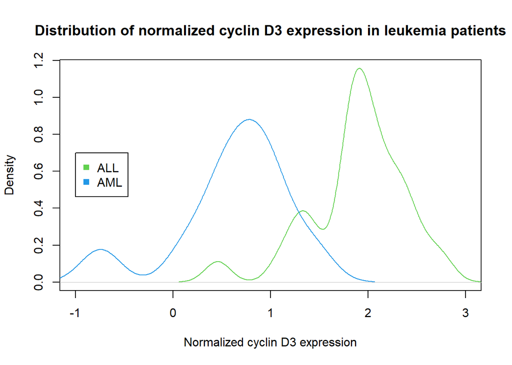

```r
# create main plot with ALL data
plot(density(golub[1042,gol.fac=="ALL"]), xlim=c(-1,3), xlab="Normalized cyclin D3 expression", main="Distribution of normalized cyclin D3 expression in leukemia patients", col=3)

# overlay AML data
lines(density(golub[1042,gol.fac=="AML"]), col=4)

# add a legend
legend(x=-1,y=0.7, legend=c("ALL","AML"),pch=15, col=c(3,4))
```

3.10

The curves are probability distributions and we can interpret them as such. As an example, we would use the plot to get the probability of AML patients that have a normalized cyclin D3 expression within a specific range by integrating (finding the area under the curve) the AML curve within that range.

RUN THE FOLLOWING PREREQUISITE CODE

```r
install.packages("seqinr", repos='http://cran.us.r-project.org')
library("seqinr")
E_coli <- read.fasta(file="E_coli.fasta")
```

4.1

```r
# Define a vector in R called myvec containing the integers between 7 and 21
myvec <- c(7:21)

# use indexing to replace the third entry of myvec with the character string “Hi”
myvec[3] <- "Hi"

print(myvec)
```

```
##  [1] "7"  "8"  "Hi" "10" "11" "12" "13" "14" "15" "16" "17" "18" "19" "20" "21"
```

When I set one of the indices of myvec to a string (“Hi”), all of the previously integer elements in the array got converted to a string format. I think this happened because all elements in a vector in R must share a common type.

4.2

```r
# Write a function that takes in a list and prints out what type of object is stored in each element of the list
element_type <- function(lst){
  for (element in lst){
    print(class(element))
  }
}

motleyCrew <- list(char = c("a", "b", "c"), num = 1:7, func = sample, logic = TRUE, missing = NA, numberList = list(one = 1, two = 2, three = 3))

element_type(motleyCrew)
```

```
## [1] "character"
## [1] "integer"
## [1] "function"
## [1] "logical"
## [1] "logical"
## [1] "list"
```

4.3

```r
# determine the total number of nucleotides in the E_coli genome sequence
Ecoli_seq <- E_coli[[1]]
numNucleotides <- length(Ecoli_seq)
numNucleotides
```

```
## [1] 4641652
```

4.4

```r
# Print out the last 200 nucleotides of the E_coli genome sequence
NUM_NUCLEOTIDES <- 200
Ecoli_seq[(length(Ecoli_seq)-NUM_NUCLEOTIDES+1):length(Ecoli_seq)]
```

```
##   [1] "a" "a" "c" "a" "t" "c" "a" "a" "c" "t" "g" "c" "a" "a" "g" "c" "t" "t"
##  [19] "t" "a" "c" "g" "c" "g" "a" "a" "c" "g" "a" "g" "c" "c" "a" "t" "g" "a"
##  [37] "c" "a" "t" "t" "g" "c" "t" "g" "a" "c" "g" "a" "c" "t" "c" "t" "g" "g"
##  [55] "c" "a" "g" "t" "g" "g" "c" "a" "g" "a" "t" "g" "a" "c" "a" "t" "a" "a"
##  [73] "a" "a" "c" "t" "g" "g" "t" "c" "g" "a" "c" "t" "g" "g" "t" "t" "a" "c"
##  [91] "a" "a" "c" "a" "a" "c" "g" "c" "c" "t" "g" "g" "g" "g" "c" "t" "t" "t"
## [109] "t" "a" "g" "a" "g" "c" "a" "a" "c" "g" "a" "g" "a" "c" "a" "c" "g" "g"
## [127] "c" "a" "a" "t" "g" "t" "t" "g" "c" "a" "c" "c" "g" "t" "t" "t" "g" "c"
## [145] "t" "g" "c" "a" "t" "g" "a" "t" "a" "t" "t" "g" "a" "a" "a" "a" "a" "a"
## [163] "a" "t" "a" "t" "c" "a" "c" "c" "a" "a" "a" "t" "a" "a" "a" "a" "a" "a"
## [181] "c" "g" "c" "c" "t" "t" "a" "g" "t" "a" "a" "g" "t" "a" "t" "t" "t" "t"
## [199] "t" "c"
```

4.5

```r
# Find the individual nucleotide counts for the E_coli genome
counts <- table(Ecoli_seq)
counts
```

```
## Ecoli_seq
##       a       c       g       t
## 1142742 1180091 1177437 1141382
```

```r
# What would the counts be for a DNA strand complimentary to this one
countsComplement <- table(c("a", "c", "g", "t"))

# set values in table countComplements
countsComplement[["a"]] = counts[["t"]]
countsComplement[["t"]] = counts[["a"]]
countsComplement[["g"]] = counts[["c"]]
countsComplement[["c"]] = counts[["g"]]

countsComplement
```

```
##
##       a       c       g       t
## 1141382 1177437 1180091 1142742
```

4.6

```r
# Write a pair of functions called frequencyPyrimidine() and frequencyPurine() such that, given a nucleotide sequence, they will output the respective frequencies of pyrimidines and purines

frequencyPyrimidine <- function(sequence){
  return((sum(sequence == "c") + sum(sequence == "t")) / length(sequence))
}

frequencyPurine <- function(sequence){
  return((sum(sequence == "a") + sum(sequence == "g")) / length(sequence))
}
```

4.7a  
The masses of Ribonucleotide Monophosphates and Deoxyribonucleotide monophosphates are different because the sugar backbone of Ribonucleotide Monophosphates have an extra oxygen atom (because of the hydroxyl group on the 2’ carbon)

4.7b

```r
# given a nucleotide sequence, outputs its weight
seqWeight <- function(sequence, type="DNA"){
  if(type == "RNA"){
    return(sum(sequence == "a")*329.2 + sum(sequence == "c")*305.2 + sum(sequence == "g")*345.2 + sum(sequence == "u")*306.2)
  }
  else {
    return(sum(sequence == "a")*313.2 + sum(sequence == "c")*289.2 + sum(sequence == "g")*329.2 + sum(sequence == "t")*304.2)
  }
}
```

4.7c

```r
# Output weight of the following DNA sequence
seq <- c("g", "a", "t", "a", "t", "t", "c", "g", "g", "a", "g", "g", "g", "g")
seqWeight(seq)
```

```
## [1] 4445.8
```

4.8

```r
# given a DNA sequence, output the complementary strand
compStrand <- function(seq){
  map=c("A"="T", "T"="A","G"="C","C"="G")
  compl <- seq
  for(i in 1:length(compl)){
    compl[i] <- as.character(map[seq[i]])
  }
  return(rev(compl))
}
```

4.9

```r
# function that will take in as its argument a nucleotide sequence and then return its GC content

GC_Content <- function(seq){
  return((sum(seq == "g")+sum(seq == "c")) / length(seq))
}

GC_Content(Ecoli_seq)
```

```
## [1] 0.5079071
```

```r
GC(Ecoli_seq)
```

```
## [1] 0.5079071
```

The GC content of the Ecoli sequence is 0.508, which is in agreement with the built in GC function in R.

4.10

```r
#  takes a nucleotide sequence’s length, a window size, and a step size as arguments and outputs a sequence of numbers containing the starting nucleotide position of each window that fully fits within the sequence

windowStartPositions <- function(len, windowSize, stepSize){
  return(seq(1, len-windowSize+1, by=stepSize))
}
```

4.11

```r
#  takes a nucleotide sequence, a window size, and a step size as arguments and outputs a numeric vector containing the GC content of each window

slidingGC <- function(seq, windowSize, stepSize){
  startPos <- windowStartPositions(length(seq), windowSize, stepSize)

  GC <- startPos
  for(i in 1:length(startPos)){
    GC[i] <- GC_Content(seq[startPos[i]:(startPos[i]+windowSize-1)])
  }
  return(GC)
}
```

4.12

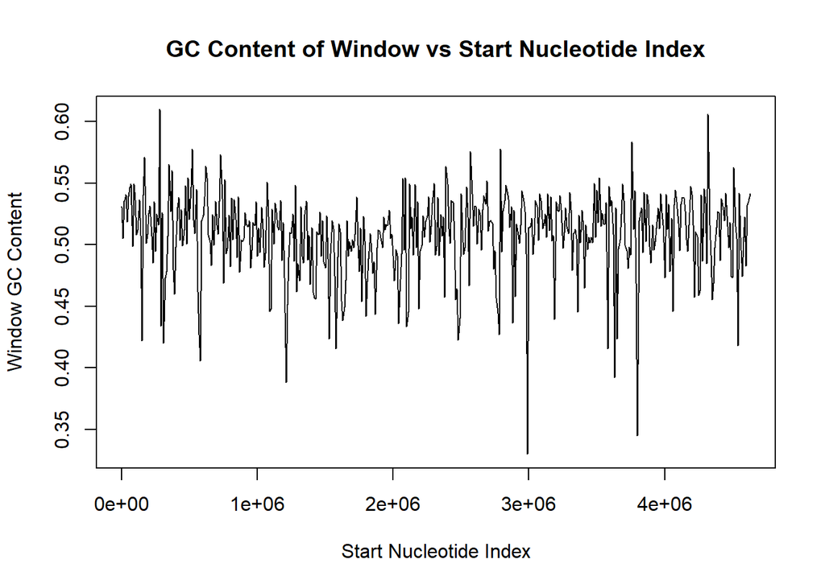

```r
# takes a nucleotide sequence, a window size, and a step size as arguments and plots a scatter plot of the GC content of each window against the starting nucleotide position of each window

plotSlidingGC <- function(seq, windowSize, stepSize){
  windowStarts <- windowStartPositions(length(seq), windowSize, stepSize)
  GC_slide <- slidingGC(seq, windowSize, stepSize)
  plot(windowStarts, GC_slide, pch='.', type='o', xlab="Start Nucleotide Index", ylab="Window GC Content", main="GC Content of Window vs Start Nucleotide Index")
}

plotSlidingGC(Ecoli_seq, 5000, 10000)
```

Increasing the step size makes the graph more smooth/less granular. A small step size makes the graph fluctuate at the micro scale a lot more. Larger window sizes makes the GC content average out and therefore the Window GC content stays around 0.5. Smaller window sizes are more prone to sudden large dips/gains in GC content.